# Character Deaths in A Song of Ice and Fire

Naixin Zhu

6/29/2019

# 1 Introduction

George R. R. Martin’s novel, A Song of Ice and Fire, is a based on an imaginary world of medieval kingdoms. The books are well-known for the HBO show Game of Throne. The books created a plethora of characters, from nameless commoners to princesses and princes. The author is well known for killing off its characters frequently, on average a character dies every dozen page. The setting is cold weapon era, without rule of law and advance medicine, civilized culture live alongside barbarians and people’s life expectancy is likely to be short, for various reasons. Nevertheless, one important questions to ask is, does the author kill characters randomly, or there are some features that could significantly predict probability of death?

In order to answer the above question quantitatively, I will conduct Bayesian logistic regression with inclusion factors, to see which features are most important in determining death. I will compare the Bayesian regression with frequentist regression and they all yield same sign and significance level for certain sets of variables.

# 2 Data

I will use Kaggle dataset “Game of Thrones – Explore Deaths and Battles from this Fantasy World”, published by Myles O’Neill on 19 May 2016.

# 3 Descriptive Statistics

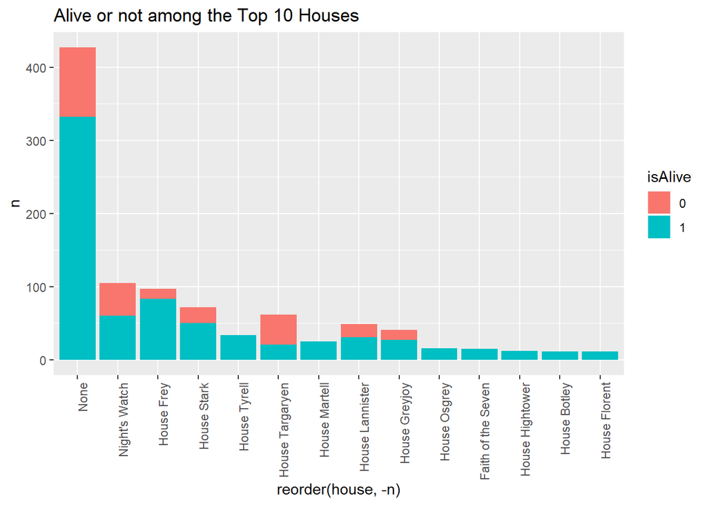

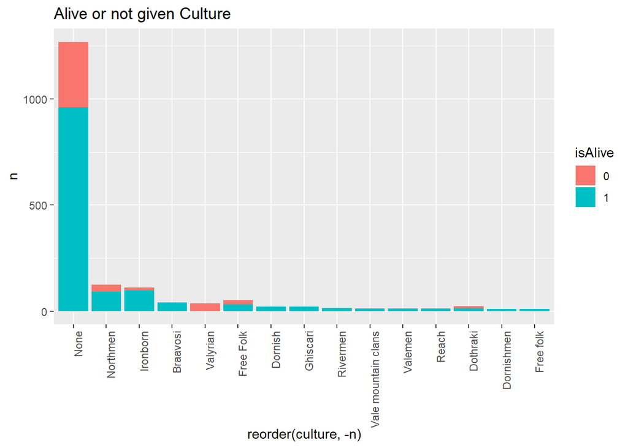

The bar chart below shows dead/alive ratio within popular/none-popular groups. We can see that even though vast majority of characters are not popular, but the ratio of dead is porportionately higher in the popular group. This is probably the curse of attracting attentions.

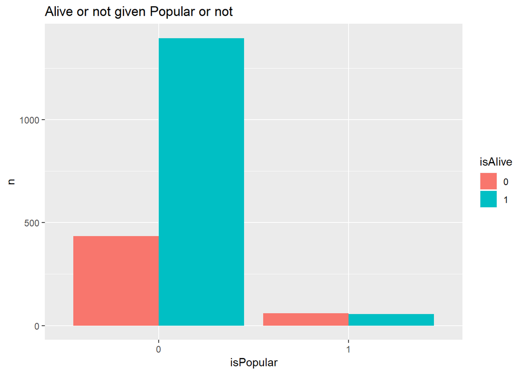

The two bar charts below show the dead/alive ratio within nobility groups and gender groups.

For gender group, we see than dead is proportionately higher for male, which is quite straightforward. In the setting of the story, men need to go and fight and they are more likely to die. However, it is a bit surprising that being noble or not does not affect your chance of dead. After some thought, this is also reasonable since in the story setting, having more money and higher status does not shield one from war, disease and conspiracy, which all cost lives.

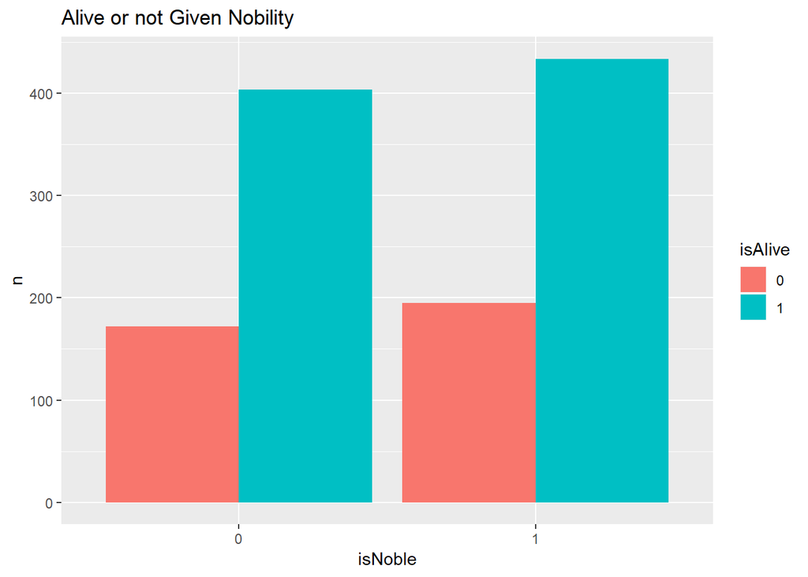

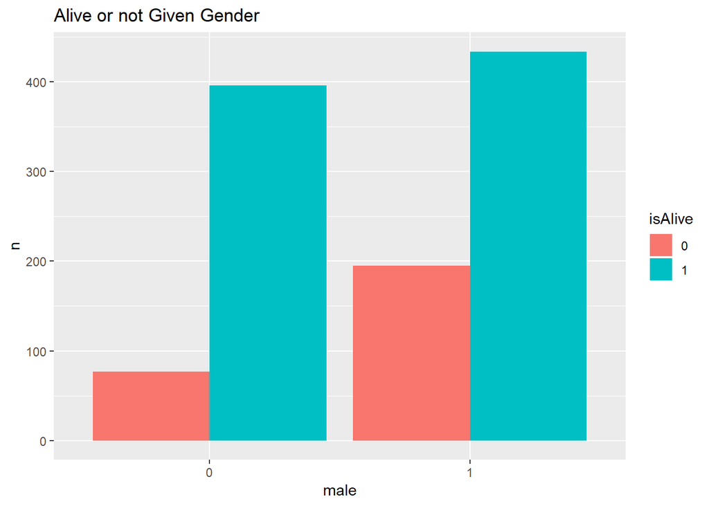

# 4 Feature Selection

Since I am interested in the causal relationship between individual houses and cultures to the probabilty of death, I would like to turn the categorical variables into binary dummies and obtained 413 new dummy variables, each representing a single house or a single culture. I cannot possibly put them all into a frequentist linear regression, let along using MCMC on that many features. Therefore, feature selection is essential in the project.

Finally I obtained a list of variables that will be feeded into MCMC in JAGS.

```
## Morgan-Tatar search since family is non-gaussian.
```

```
##   culture.Free Folk culture.Ironborn culture.None culture.Northmen
## 1              TRUE             TRUE        FALSE            FALSE
## 2              TRUE             TRUE        FALSE            FALSE
## 3              TRUE             TRUE         TRUE            FALSE
## 4              TRUE             TRUE        FALSE            FALSE
## 5              TRUE             TRUE        FALSE            FALSE
##   culture.other_culture culture.Valyrian male isPopular isNoble isMarried
## 1                 FALSE             TRUE TRUE      TRUE   FALSE     FALSE
## 2                 FALSE             TRUE TRUE      TRUE    TRUE     FALSE
## 3                 FALSE             TRUE TRUE      TRUE   FALSE     FALSE
## 4                  TRUE             TRUE TRUE      TRUE   FALSE     FALSE
## 5                 FALSE             TRUE TRUE      TRUE   FALSE      TRUE
##   Criterion
## 1  2059.062
## 2  2060.355
## 3  2060.839
## 4  2060.904
## 5  2061.006
```

```
##  culture.Free Folk culture.Ironborn culture.None    culture.Northmen
##  Mode:logical      Mode:logical     Mode :logical   Mode :logical
##  TRUE:5            TRUE:5           FALSE:4         FALSE:5
##                                     TRUE :1
##
##
##
##  culture.other_culture culture.Valyrian   male         isPopular
##  Mode :logical         Mode:logical     Mode:logical   Mode:logical
##  FALSE:4               TRUE:5           TRUE:5         TRUE:5
##  TRUE :1
##
##
##
##   isNoble        isMarried         Criterion
##  Mode :logical   Mode :logical   Min.   :2059
##  FALSE:4         FALSE:4         1st Qu.:2060
##  TRUE :1         TRUE :1         Median :2061
##                                  Mean   :2060
##                                  3rd Qu.:2061
##                                  Max.   :2061
```

```
## Morgan-Tatar search since family is non-gaussian.
```

```
##   house.House Frey house.House Stark house.House Targaryen
## 1             TRUE             FALSE                  TRUE
## 2             TRUE             FALSE                  TRUE
## 3             TRUE              TRUE                  TRUE
## 4             TRUE              TRUE                  TRUE
## 5            FALSE             FALSE                  TRUE
##   house.Night's Watch house.None house.other_house male isPopular isNoble
## 1                TRUE      FALSE             FALSE TRUE      TRUE   FALSE
## 2                TRUE      FALSE             FALSE TRUE      TRUE   FALSE
## 3                TRUE      FALSE             FALSE TRUE      TRUE   FALSE
## 4                TRUE      FALSE             FALSE TRUE      TRUE   FALSE
## 5                TRUE      FALSE             FALSE TRUE      TRUE   FALSE
##   isMarried Criterion
## 1      TRUE  2072.149
## 2     FALSE  2072.358
## 3      TRUE  2073.501
## 4     FALSE  2073.657
## 5     FALSE  2073.684
```

```
##  house.House Frey house.House Stark house.House Targaryen
##  Mode :logical    Mode :logical     Mode:logical
##  FALSE:1          FALSE:3           TRUE:5
##  TRUE :4          TRUE :2
##
##
##
##  house.Night's Watch house.None      house.other_house   male
##  Mode:logical        Mode :logical   Mode :logical     Mode:logical
##  TRUE:5              FALSE:5         FALSE:5           TRUE:5
##
##
##
##
##  isPopular       isNoble        isMarried         Criterion
##  Mode:logical   Mode :logical   Mode :logical   Min.   :2072
##  TRUE:5         FALSE:5         FALSE:3         1st Qu.:2072
##                                 TRUE :2         Median :2074
##                                                 Mean   :2073
##                                                 3rd Qu.:2074
##                                                 Max.   :2074
```

## 4.1 check for multicollinearity

As we can see the correlation matrix below, the variables are correlated but to a tolerable degree.

|  | house.House Frey | house.House Stark | house.House Targaryen | house.Night’s Watch | house.None | house.other_house | culture.Free Folk | culture.Ironborn | culture.None | culture.Northmen | culture.other_culture | culture.Valyrian | male | isPopular | isNoble | isMarried |
| --- | --- | --- | --- | --- | --- | --- | --- | --- | --- | --- | --- | --- | --- | --- | --- | --- |
| house.House Frey | 1.00 | -0.04 | -0.04 | -0.05 | -0.12 | -0.29 | -0.04 | -0.06 | 0.13 | -0.06 | -0.06 | -0.03 | -0.03 | -0.04 | -0.09 | 0.12 |
| house.House Stark | -0.04 | 1.00 | -0.04 | -0.05 | -0.10 | -0.24 | -0.03 | -0.05 | -0.20 | 0.48 | -0.01 | -0.03 | 0.02 | 0.08 | -0.02 | 0.01 |
| house.House Targaryen | -0.04 | -0.04 | 1.00 | -0.04 | -0.10 | -0.23 | -0.03 | -0.04 | -0.13 | -0.05 | 0.01 | 0.55 | -0.04 | 0.05 | 0.09 | 0.14 |
| house.Night’s Watch | -0.05 | -0.05 | -0.04 | 1.00 | -0.13 | -0.30 | -0.04 | -0.05 | 0.14 | -0.06 | -0.07 | -0.04 | 0.07 | -0.04 | -0.16 | -0.10 |
| house.None | -0.12 | -0.10 | -0.10 | -0.13 | 1.00 | -0.66 | 0.30 | -0.04 | -0.09 | -0.10 | 0.10 | -0.06 | -0.05 | 0.01 | -0.18 | -0.16 |
| house.other_house | -0.29 | -0.24 | -0.23 | -0.30 | -0.66 | 1.00 | -0.20 | 0.11 | 0.08 | -0.03 | -0.02 | -0.10 | 0.03 | -0.03 | 0.24 | 0.07 |
| culture.Free Folk | -0.04 | -0.03 | -0.03 | -0.04 | 0.30 | -0.20 | 1.00 | -0.04 | -0.22 | -0.04 | -0.08 | -0.02 | -0.02 | -0.04 | -0.12 | -0.02 |
| culture.Ironborn | -0.06 | -0.05 | -0.04 | -0.05 | -0.04 | 0.11 | -0.04 | 1.00 | -0.34 | -0.06 | -0.12 | -0.04 | 0.06 | -0.03 | -0.09 | -0.08 |
| culture.None | 0.13 | -0.20 | -0.13 | 0.14 | -0.09 | 0.08 | -0.22 | -0.34 | 1.00 | -0.36 | -0.64 | -0.21 | -0.04 | -0.10 | 0.04 | -0.02 |
| culture.Northmen | -0.06 | 0.48 | -0.05 | -0.06 | -0.10 | -0.03 | -0.04 | -0.06 | -0.36 | 1.00 | -0.12 | -0.04 | 0.05 | 0.08 | 0.02 | 0.04 |
| culture.other_culture | -0.06 | -0.01 | 0.01 | -0.07 | 0.10 | -0.02 | -0.08 | -0.12 | -0.64 | -0.12 | 1.00 | -0.07 | -0.01 | 0.08 | -0.01 | -0.01 |
| culture.Valyrian | -0.03 | -0.03 | 0.55 | -0.04 | -0.06 | -0.10 | -0.02 | -0.04 | -0.21 | -0.04 | -0.07 | 1.00 | 0.00 | 0.10 | 0.12 | 0.17 |
| male | -0.03 | 0.02 | -0.04 | 0.07 | -0.05 | 0.03 | -0.02 | 0.06 | -0.04 | 0.05 | -0.01 | 0.00 | 1.00 | 0.13 | 0.16 | -0.08 |
| isPopular | -0.04 | 0.08 | 0.05 | -0.04 | 0.01 | -0.03 | -0.04 | -0.03 | -0.10 | 0.08 | 0.08 | 0.10 | 0.13 | 1.00 | 0.12 | 0.16 |
| isNoble | -0.09 | -0.02 | 0.09 | -0.16 | -0.18 | 0.24 | -0.12 | -0.09 | 0.04 | 0.02 | -0.01 | 0.12 | 0.16 | 0.12 | 1.00 | 0.16 |
| isMarried | 0.12 | 0.01 | 0.14 | -0.10 | -0.16 | 0.07 | -0.02 | -0.08 | -0.02 | 0.04 | -0.01 | 0.17 | -0.08 | 0.16 | 0.16 | 1.00 |

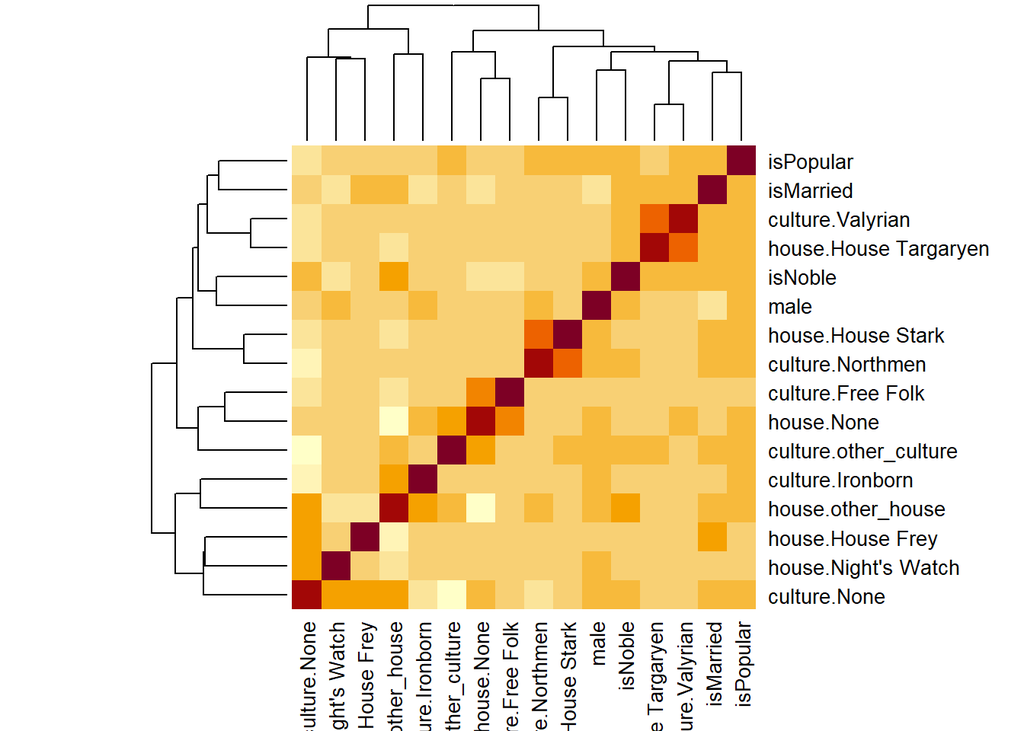

```
##
## Call:
## glm(formula = isAlive ~ `house.House Frey` + `house.House Targaryen` +
##     `house.Night's Watch` + `culture.Free Folk` + culture.Ironborn +
##     culture.Valyrian + male + isPopular + isMarried, family = "binomial",
##     data = df_feature_selection)
##
## Deviance Residuals:
##     Min       1Q   Median       3Q      Max
## -2.3068  -0.3963   0.5591   0.7803   2.3857
##
## Coefficients:
##                         Estimate Std. Error z value Pr(>|z|)
## (Intercept)               1.7769     0.1107  16.055  < 2e-16 ***
## `house.House Frey`        0.5437     0.3024   1.798  0.07217 .
## `house.House Targaryen`  -1.1134     0.3406  -3.269  0.00108 **
## `house.Night's Watch`    -0.9076     0.2112  -4.298 1.73e-05 ***
## `culture.Free Folk`      -0.7160     0.3044  -2.352  0.01865 *
## culture.Ironborn          0.8113     0.2952   2.748  0.00600 **
## culture.Valyrian         -2.3048     0.4912  -4.692 2.70e-06 ***
## male1                    -0.7437     0.1233  -6.029 1.65e-09 ***
## isPopular1               -1.0246     0.2097  -4.887 1.02e-06 ***
## isMarried1               -0.1199     0.1654  -0.725  0.46856
## ---
## Signif. codes:  0 '***' 0.001 '**' 0.01 '*' 0.05 '.' 0.1 ' ' 1
##
## (Dispersion parameter for binomial family taken to be 1)
##
##     Null deviance: 2207.1  on 1945  degrees of freedom
## Residual deviance: 2017.2  on 1936  degrees of freedom
## AIC: 2037.2
##
## Number of Fisher Scoring iterations: 4
```

# 5 Bayesian Robust Logistic Regression Analysis

## 5.1 Hierarchical Model 1: Robusines Bayesian Logistic Regression

citation(Textbook: page 635)

$$y \sim dbern(\mu)$$

The below expression is robuts in a way that allows data to come from two sources. $\alpha$ is generally smaller than $1-\alpha$, and it allows a small protion of data is coming from randomly gussing. Meanwhile, the majority of the data are coming from the logistic regression. This is robust to outliers, and in the conclusion you will see the comparison between the robust model and non-robust, and there is a difference.

$$\mu = \alpha \frac{1}{2} + (1 - \alpha) logistic(\beta_{0} + \sum_j \beta_jx_j)$$

$$\alpha \sim dbeta(1,9)$$

$$z\beta_0 \sim dnorm(0, 0.5^2)$$

$$z\beta_j \sim dnorm(0, 0.5^2)$$

[output not shown]

## 5.2 Hierarchical Model 2: Bayesian Logistic Regression with Inclusion Factors

In order to compare how the model performs with and without the robustness, I would like to perform a non-robust model. I have included the inclusion factor $\delta$ that is binary: 1 indicates the variable should included, while 0 indicates the variable should not be included.

$$y \sim dbern(\mu)$$

$$\mu = logistic(\beta_{0} + \sum_j \delta_j \beta_jx_j)$$

$$\delta \sim dbern(0.5)$$

$$z\beta_0 \sim dnorm(0, 0.5^2)$$

$$z\beta_j \sim dnorm(0, 0.5^2)$$

# 6 Results and Conclusion

However, we can still observe the difference between robust and non-robust model: - For House Targaryen, the outlier changes its estimate. In the robust model, outlier the Dragon Queen, does not affect the overall bleak outlook of house Targaryen. Nonetheless, in the none-robust model, the probability of death is reduced by the few survivors of house Targaryen.

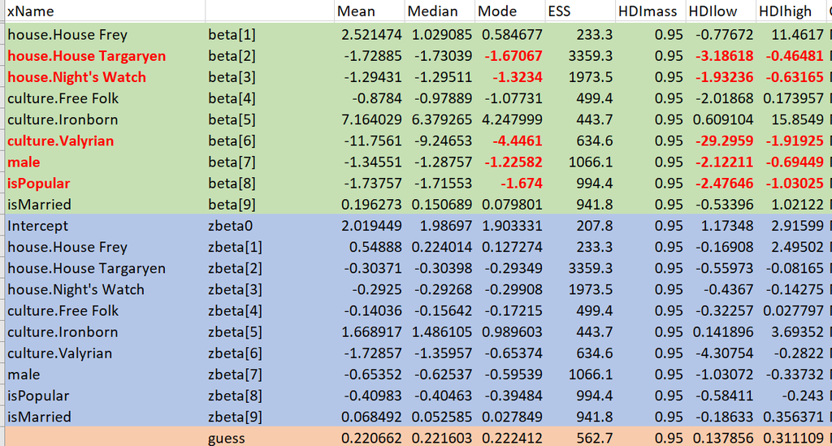

Table 1. Results of Bayesian Robust Logistic Regression

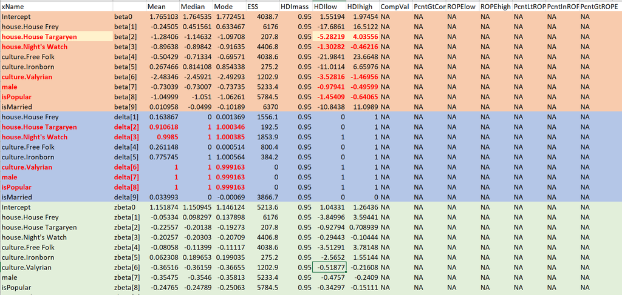

Table 2. Results of None-robuts Bayesian Logistic Regression with Inclusion Factor

The table below shows that frequentist logistic regression yield the similar results as both Bayesian models.

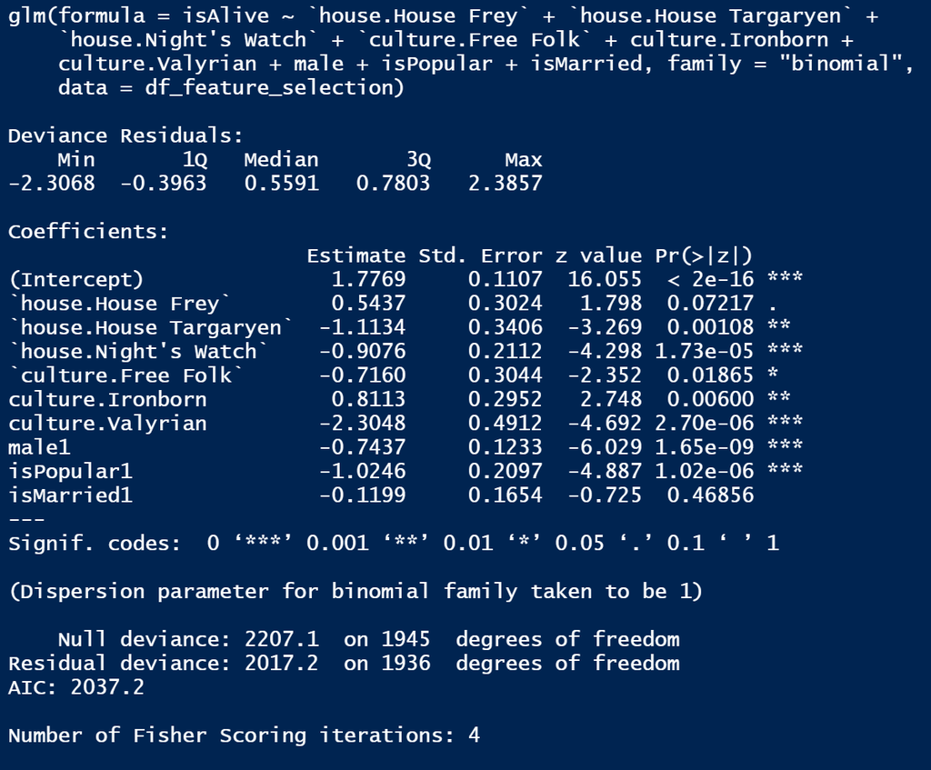

Table 3. Results of Frequentist Logistic Regression

We can take a look at some posterior distrbution from robust Bayesian logistic models:

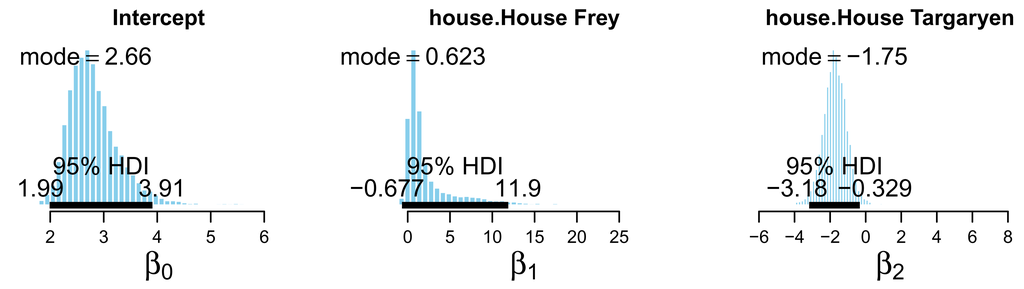

[figure not shown]

Figure 2. Posterior Distribution of Robust Bayesian Logistic Regression

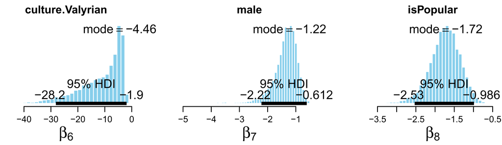

Figure 3. Posterior Distribution of Robust Bayesian Logistic Regression

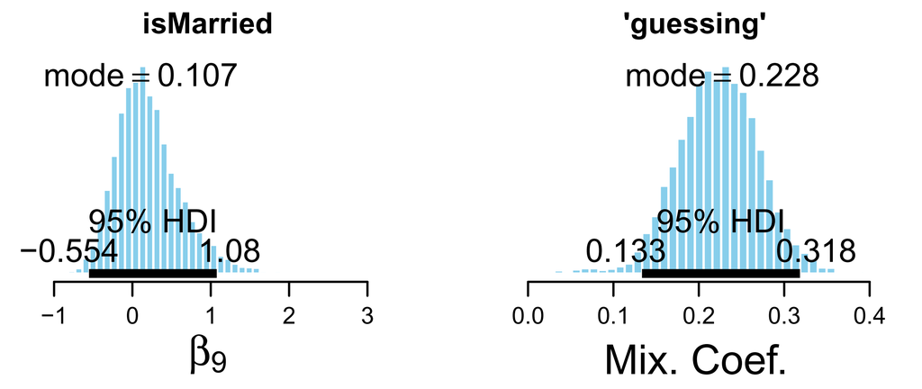

Figure 4. Posterior Distribution of Robust Bayesian Logistic Regression

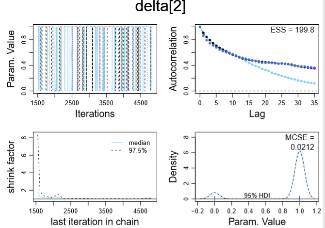

Figure 5. Inclusion Factor for House Targaryen

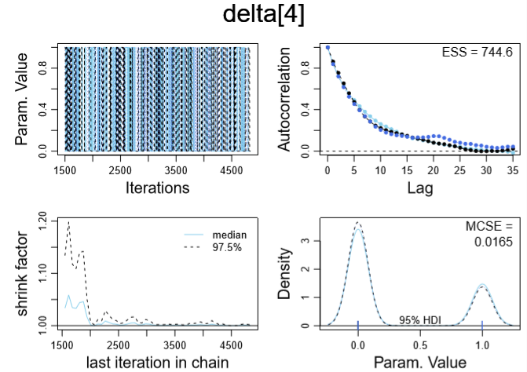

Figure 6. Inclusion Factor for Culture Freefolk

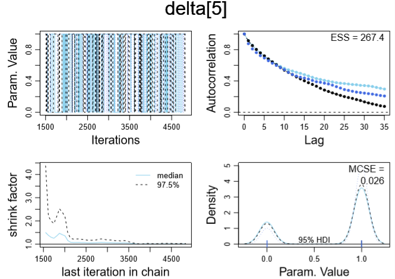

Figure 7. Inclusion Factor for Culture Ironborn

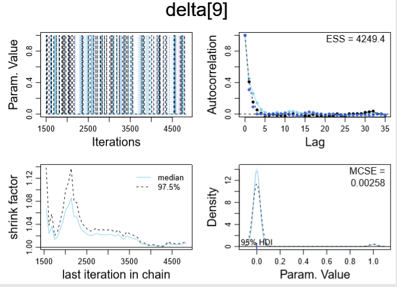

Figure 8. Inclusion Factor for isMarried

There are some potential problems with the dataset that might bias the analysis. First, I do not know how the variable “isAlive” is coded. The ones that are coded 0 under “isAlive” is for sure dead because the book explicitly portrayed them so. However, for most characters that do not deserve author’s attention, we are unclear whether they are alive by the end of book 5.

Another variable I could have used but did not is the appearances in the book. They are binary variables indicating whether a character appeared in a book, from book 1 to book 5. This could have a direct correlation to “isAlive”, adding this variable to the regression as a control would probably make other effect insignificant.

The project is a good start place for me to use Bayesian logistic regression, which I believe I will use in many empirical economic researches. As for the topic itself, even though it does not seem to be “serious” research, it contributes to the general discussion of “artificial intelligence” and its influence in artistic creation. I believe soon, or it could have happened already, that AI could generate novel plots for us according to our taste. Then what will be the role of human creativity play?